# Отчет по лабораторной работе №11

Отчет о настройке GRUB2 и процедурах восстановления системы

Чилеше . Л

Российский университет дружбы народов, Москва, Россия

Объединённый институт ядерных исследований, Дубна, Россия

27 января 2003

# Информация

## Докладчик

- Лупупа Чилеше
- Студент
- Студент Группы НПИбд-03-23
- Российский университет дружбы народов

# Вводная часть

## Цель работ

Получить навыки работы с загрузчиком системы GRUB2.

## Введение

В этом отчете описаны шаги, необходимые для управления конфигурациями загрузчика GRUB2, диагностики системных проблем, а также восстановления или сброса пароля root в дистрибутивах Linux на основе Red Hat. Эти задачи необходимы системным администраторам для обеспечения стабильности системы, устранения ошибок и восстановления доступа, когда учетные данные недоступны.

## Конфигурация GRUB2

Загрузчик GRUB2 играет решающую роль в управлении процессом загрузки в Linux. Настройка его параметров позволяет оптимизировать и эффективный запуск системы.

## Изменение тайм-аута GRUB:

- Тайм-аут по умолчанию для отображения меню GRUB можно настроить в файле /etc/default/grub, установив для параметра GRUB_TIMEOUT желаемое значение (например, 10 секунд).
- Изменения применяются с помощью команды: grub2-mkconfig -o /boot/grub2/grub.cfg
- Это гарантирует, что у пользователей будет достаточно времени для выбора параметров загрузки во время запуска.

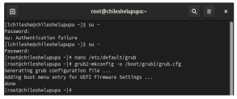

## Отображение загрузочных сообщений:

- Удалив параметры rhgb (графическая загрузка Red Hat) и quiet из строки GRUB_CMDLINE_LINUX в файле конфигурации GRUB, можно включить подробные загрузочные сообщения. Это полезно для диагностики проблем во время процесса загрузки

# Процедуры восстановления системы

Режимы восстановления системы, такие как режим восстановления и аварийный режим, жизненно важны для устранения сбоев загрузки и других критических проблем.

## 1. Rescue Mode:

- Режим восстановления — это минимально функциональная среда, позволяющая администраторам диагностировать и устранять проблемы.
- Доступ включается путем редактирования записи GRUB во время загрузки, добавления systemd.unit=rescue.target к строке ядра и нажатия Ctrl + X для продолжения загрузки.
- Такие команды, как systemctl list-units и systemctl show-environment, предоставляют информацию о загруженных сервисах и переменных среды.

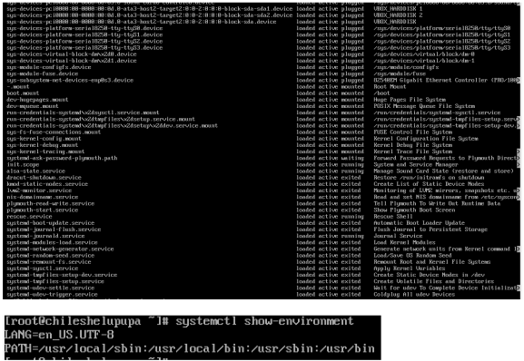

## Emergency Mode:

- Этот режим предоставляет минимальную оболочку, в которую загружаются только самые основные системные ресурсы. Он используется, когда проблемы не позволяют системе загрузиться в режиме восстановления.
- Как и в режиме восстановления, доступ включается добавлением systemd.unit=emergency.target к строке ядра

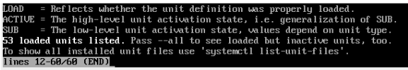

# Сброс пароля root

Распространенным сценарием системного администрирования является потеря пароля root. Следующие шаги описывают процедуру его сброса:

## Доступ к Initramfs:

- При добавлении rd.break к строке ядра в GRUB и загрузке система останавливается на этапе initramfs перед монтированием корневой
- файловой системы.

## Перемонтирование файловой системы для доступа на чтение/запись:

Корневая файловая система перемонтируется для доступа на запись с помощью: mount -o remount,rw /sysroot chroot /sysroot

## Установка нового пароля:

- Команда passwd используется для назначения нового пароля пользователю root.

## Восстановление контекста SELinux:

Поскольку на этом этапе политики SELinux не загружаются, контекст теневого файла необходимо исправить вручную: load_policy -i chcon -t shadow_t /etc/shadow

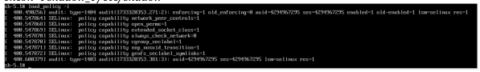

## Перезагрузка системы:

Система перезагружается с помощью команды restart -f, гарантируя, что изменения будут применены.

## Заключение

Понимание и управление конфигурациями GRUB2, использование режимов восстановления и сброс пароля root являются критически важными навыками для поддержания доступности и безопасности системы. Эти знания позволяют администраторам эффективно реагировать на чрезвычайные ситуации, сводя к минимуму время простоя и обеспечивая надежность системы. Этот отчет служит справочником по систематическому выполнению этих задач, подчеркивая важность тщательного выполнения для предотвращения дальнейших осложнений.